# Klasifikasi Breast Cancer dengan Naive Bayes

yohanesegipratama

2022-11-16

# Objectives

Analisis ini bertujuan untuk mengamati fitur mana yang paling membantu dalam memprediksi kanker ganas atau jinak dan untuk melihat tren umum yang dapat membantu kita dalam pemilihan model dan pemilihan parameter hiper. Tujuannya adalah untuk mengklasifikasikan apakah kanker payudara tersebut jinak atau ganas. Untuk mencapai ini saya menggunakan metode naive bayes

# library

```r
library(tidyverse)
library(caret)
library(e1071)
library(visdat)
```

```r
library(cowplot)
library(corrplot)
```

# load data

```r
df = read.csv('data_input/data.csv')
head(df)
```

```
##         id diagnosis radius_mean texture_mean perimeter_mean area_mean
## 1   842302         M       17.99        10.38         122.80    1001.0
## 2   842517         M       20.57        17.77         132.90    1326.0
## 3 84300903         M       19.69        21.25         130.00    1203.0
## 4 84348301         M       11.42        20.38          77.58     386.1
## 5 84358402         M       20.29        14.34         135.10    1297.0
## 6   843786         M       12.45        15.70          82.57     477.1
##   smoothness_mean compactness_mean concavity_mean concave.points_mean
## 1         0.11840          0.27760         0.3001             0.14710
## 2         0.08474          0.07864         0.0869             0.07017
## 3         0.10960          0.15990         0.1974             0.12790
## 4         0.14250          0.28390         0.2414             0.10520
## 5         0.10030          0.13280         0.1980             0.10430
## 6         0.12780          0.17000         0.1578             0.08089
##   symmetry_mean fractal_dimension_mean radius_se texture_se perimeter_se
```

[output cut: 34 more lines]

# Data Preparation

## Check Missing Value

```r
colSums(is.na(df))
```

```
##                      id               diagnosis             radius_mean
##                       0                       0                       0
##            texture_mean          perimeter_mean               area_mean
##                       0                       0                       0
##         smoothness_mean        compactness_mean          concavity_mean
##                       0                       0                       0
##     concave.points_mean           symmetry_mean  fractal_dimension_mean
##                       0                       0                       0
##               radius_se              texture_se            perimeter_se
##                       0                       0                       0
##                 area_se           smoothness_se          compactness_se
##                       0                       0                       0
##            concavity_se       concave.points_se             symmetry_se
##                       0                       0                       0
##    fractal_dimension_se            radius_worst           texture_worst
##                       0                       0                       0
##         perimeter_worst              area_worst        smoothness_worst
##                       0                       0                       0
##       compactness_worst         concavity_worst    concave.points_worst
##                       0                       0                       0
##          symmetry_worst fractal_dimension_worst                       X
##                       0                       0                     569
```

```r
glimpse(df)
```

```
## Rows: 569
## Columns: 33
## $ id                      <int> 842302, 842517, 84300903, 84348301, 84358402, …
## $ diagnosis               <chr> "M", "M", "M", "M", "M", "M", "M", "M", "M", "…
## $ radius_mean             <dbl> 17.990, 20.570, 19.690, 11.420, 20.290, 12.450…
## $ texture_mean            <dbl> 10.38, 17.77, 21.25, 20.38, 14.34, 15.70, 19.9…
## $ perimeter_mean          <dbl> 122.80, 132.90, 130.00, 77.58, 135.10, 82.57, …
## $ area_mean               <dbl> 1001.0, 1326.0, 1203.0, 386.1, 1297.0, 477.1, …
## $ smoothness_mean         <dbl> 0.11840, 0.08474, 0.10960, 0.14250, 0.10030, 0…
## $ compactness_mean        <dbl> 0.27760, 0.07864, 0.15990, 0.28390, 0.13280, 0…
## $ concavity_mean          <dbl> 0.30010, 0.08690, 0.19740, 0.24140, 0.19800, 0…
## $ concave.points_mean     <dbl> 0.14710, 0.07017, 0.12790, 0.10520, 0.10430, 0…
## $ symmetry_mean           <dbl> 0.2419, 0.1812, 0.2069, 0.2597, 0.1809, 0.2087…
## $ fractal_dimension_mean  <dbl> 0.07871, 0.05667, 0.05999, 0.09744, 0.05883, 0…
## $ radius_se               <dbl> 1.0950, 0.5435, 0.7456, 0.4956, 0.7572, 0.3345…
```

[output cut: 20 more lines]

- insight Kumpulan data kanker payudara Wisconsin berisi 569 entri yang berasal dari analisis gambar aspirasi jarum halus dari massa payudara. Kolom pertama berisi id unik dan kolom kedua berisi diagnosis.

Tidak ada nilai yang hilang kecuali kolom 33 yang terlihat kosong.

```r
# select features
df_selected <- df[1:32]

# drop id variable
Matrix <- df_selected%>%
select(-c("id"))%>%
# convert diagnosis to numerical
mutate(diagnosis = case_when(
diagnosis == "M"~1,
diagnosis == "B"~0,
))%>%
# convert to matrix
as.matrix()

# add id column as names
row.names(Matrix) <- df_selected$id
head(Matrix)
```

```
##          diagnosis radius_mean texture_mean perimeter_mean area_mean
## 842302           1       17.99        10.38         122.80    1001.0
## 842517           1       20.57        17.77         132.90    1326.0
## 84300903         1       19.69        21.25         130.00    1203.0
## 84348301         1       11.42        20.38          77.58     386.1
## 84358402         1       20.29        14.34         135.10    1297.0
## 843786           1       12.45        15.70          82.57     477.1
##          smoothness_mean compactness_mean concavity_mean concave.points_mean
## 842302           0.11840          0.27760         0.3001             0.14710
## 842517           0.08474          0.07864         0.0869             0.07017
## 84300903         0.10960          0.15990         0.1974             0.12790
## 84348301         0.14250          0.28390         0.2414             0.10520
## 84358402         0.10030          0.13280         0.1980             0.10430
## 843786           0.12780          0.17000         0.1578             0.08089
##          symmetry_mean fractal_dimension_mean radius_se texture_se perimeter_se
```

[output cut: 41 more lines]

```r
is.numeric(Matrix)
```

```
## [1] TRUE
```

## Scalling

```r
mean_sd <- cbind(as.data.frame(colMeans(Matrix)),  as.data.frame(apply(Matrix, 2, sd)))
colnames(mean_sd) <- c("Mean","SD")

mean_sd
```

```
##                                 Mean           SD
## diagnosis               3.725835e-01 4.839180e-01
## radius_mean             1.412729e+01 3.524049e+00
## texture_mean            1.928965e+01 4.301036e+00
## perimeter_mean          9.196903e+01 2.429898e+01
## area_mean               6.548891e+02 3.519141e+02
## smoothness_mean         9.636028e-02 1.406413e-02
## compactness_mean        1.043410e-01 5.281276e-02
## concavity_mean          8.879932e-02 7.971981e-02
## concave.points_mean     4.891915e-02 3.880284e-02
## symmetry_mean           1.811619e-01 2.741428e-02
## fractal_dimension_mean  6.279761e-02 7.060363e-03
## radius_se               4.051721e-01 2.773127e-01
## texture_se              1.216853e+00 5.516484e-01
## perimeter_se            2.866059e+00 2.021855e+00
## area_se                 4.033708e+01 4.549101e+01
## smoothness_se           7.040979e-03 3.002518e-03
## compactness_se          2.547814e-02 1.790818e-02
## concavity_se            3.189372e-02 3.018606e-02
## concave.points_se       1.179614e-02 6.170285e-03
## symmetry_se             2.054230e-02 8.266372e-03
## fractal_dimension_se    3.794904e-03 2.646071e-03
## radius_worst            1.626919e+01 4.833242e+00
## texture_worst           2.567722e+01 6.146258e+00
## perimeter_worst         1.072612e+02 3.360254e+01
## area_worst              8.805831e+02 5.693570e+02
## smoothness_worst        1.323686e-01 2.283243e-02
## compactness_worst       2.542650e-01 1.573365e-01
## concavity_worst         2.721885e-01 2.086243e-01
## concave.points_worst    1.146062e-01 6.573234e-02
## symmetry_worst          2.900756e-01 6.186747e-02
## fractal_dimension_worst 8.394582e-02 1.806127e-02
```

```r
ScaledMatrix <- scale(Matrix)
head(ScaledMatrix)
```

```
##          diagnosis radius_mean texture_mean perimeter_mean  area_mean
## 842302    1.296535   1.0960995   -2.0715123      1.2688173  0.9835095
## 842517    1.296535   1.8282120   -0.3533215      1.6844726  1.9070303
## 84300903  1.296535   1.5784992    0.4557859      1.5651260  1.5575132
## 84348301  1.296535  -0.7682333    0.2535091     -0.5921661 -0.7637917
## 84358402  1.296535   1.7487579   -1.1508038      1.7750113  1.8246238
## 843786    1.296535  -0.4759559   -0.8346009     -0.3868077 -0.5052059
##          smoothness_mean compactness_mean concavity_mean concave.points_mean
## 842302         1.5670875        3.2806281     2.65054179           2.5302489
## 842517        -0.8262354       -0.4866435    -0.02382489           0.5476623
## 84300903       0.9413821        1.0519999     1.36227979           2.0354398
## 84348301       3.2806668        3.3999174     1.91421287           1.4504311
## 84358402       0.2801253        0.5388663     1.36980615           1.4272370
## 843786         2.2354545        1.2432416     0.86554001           0.8239307
##          symmetry_mean fractal_dimension_mean  radius_se texture_se
```

[output cut: 41 more lines]

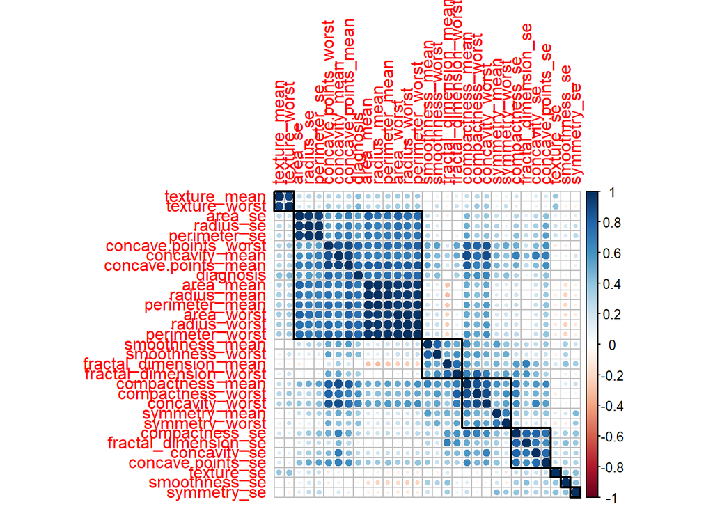

```r
options(repr.plot.width = 15, repr.plot.height = 15) # set dimensions of plots
# Plot
corrplot(cor(ScaledMatrix),
         #addCoef.col = 1,    # color numeric labels
         # = 0.8, # size numeric labels
         order = "hclust",
         tl.cex = 1, # size text label
         addrect = 8) # draw rectangle
```

# Exploratory Data Analysis

```r
df%>%
group_by(diagnosis)%>%
summarize(
    n = n())%>%
mutate(percent = paste0(round(100 * n/sum(n), 0), "%"))
```

```
## # A tibble: 2 × 3
##   diagnosis     n percent
##   <chr>     <int> <chr>
## 1 B           357 63%
## 2 M           212 37%
```

- insight Variabel hasil diagnosis memiliki kadar B untuk jinak dan M untuk ganas. Persentase kasus keganasan merupakan proporsi besar yang mengejutkan dari data dengan 37%.

# Modelling

## PCA

```r
set.seed(1)
# Perform PCA on the scaled matrix and exclude "diagnosis"
pca <- prcomp(x= ScaledMatrix[,-c(1)], scale = TRUE, center = TRUE)
summary(pca)
```

```
## Importance of components:
##                           PC1    PC2     PC3     PC4     PC5     PC6     PC7
## Standard deviation     3.6444 2.3857 1.67867 1.40735 1.28403 1.09880 0.82172
## Proportion of Variance 0.4427 0.1897 0.09393 0.06602 0.05496 0.04025 0.02251
## Cumulative Proportion  0.4427 0.6324 0.72636 0.79239 0.84734 0.88759 0.91010
##                            PC8    PC9    PC10   PC11    PC12    PC13    PC14
## Standard deviation     0.69037 0.6457 0.59219 0.5421 0.51104 0.49128 0.39624
## Proportion of Variance 0.01589 0.0139 0.01169 0.0098 0.00871 0.00805 0.00523
## Cumulative Proportion  0.92598 0.9399 0.95157 0.9614 0.97007 0.97812 0.98335
##                           PC15    PC16    PC17    PC18    PC19    PC20   PC21
## Standard deviation     0.30681 0.28260 0.24372 0.22939 0.22244 0.17652 0.1731
## Proportion of Variance 0.00314 0.00266 0.00198 0.00175 0.00165 0.00104 0.0010
## Cumulative Proportion  0.98649 0.98915 0.99113 0.99288 0.99453 0.99557 0.9966
##                           PC22    PC23   PC24    PC25    PC26    PC27    PC28
## Standard deviation     0.16565 0.15602 0.1344 0.12442 0.09043 0.08307 0.03987
## Proportion of Variance 0.00091 0.00081 0.0006 0.00052 0.00027 0.00023 0.00005
## Cumulative Proportion  0.99749 0.99830 0.9989 0.99942 0.99969 0.99992 0.99997
##                           PC29    PC30
## Standard deviation     0.02736 0.01153
## Proportion of Variance 0.00002 0.00000
## Cumulative Proportion  1.00000 1.00000
```

```r
pca_res <- as.data.frame(pca$x[,1:7])
```

```r
# extract diagnosis column
diagnosis <- df_selected[c("diagnosis")]
row.names(diagnosis) <- df$id

# merge PCA results with diagnosis
PCA_data <- merge(diagnosis, pca_res,by=0,  all=TRUE)%>%
select(-c("Row.names")) %>%
mutate(diagnosis = factor(diagnosis, levels = c("B", "M")))

# asign id as row names
row.names(PCA_data) <- df_selected$id
#head(PCA_data)
str(PCA_data)
```

```
## 'data.frame':    569 obs. of  8 variables:
##  $ diagnosis: Factor w/ 2 levels "B","M": 2 2 2 2 2 2 2 2 2 2 ...
##  $ PC1      : num  -9.18 -2.39 -5.73 -7.12 -3.93 ...
##  $ PC2      : num  -1.95 3.76 1.07 -10.27 1.95 ...
##  $ PC3      : num  -1.122 -0.529 -0.551 -3.23 1.389 ...
##  $ PC4      : num  3.631 1.117 0.911 0.152 2.938 ...
##  $ PC5      : num  1.194 -0.621 0.177 2.958 -0.546 ...
##  $ PC6      : num  1.4102 0.0286 0.541 3.0507 -1.2254 ...
##  $ PC7      : num  2.1575 0.0133 -0.6676 1.4287 -0.9354 ...
```

## Train Test Split

```r
# scale data
sc_Matrix <- scale(Matrix)
# convert to df
Scaled_df <- as.data.frame(sc_Matrix )
# add diagnosis as categories
Scaled_df <- cbind(diagnosis = df[,2],Scaled_df[,-1])
# define diagnosis as factor
Scaled_df<- Scaled_df%>%
mutate(diagnosis = factor(diagnosis, levels = c("B","M")))

# split training and testing data
Scaled_df_index <- createDataPartition(Scaled_df$diagnosis, p=0.7, list = FALSE)
training_data <- Scaled_df[Scaled_df_index,]
testing_data <- Scaled_df[-Scaled_df_index,]

# split PCA data into training and testing data
PCA_data_index <- createDataPartition(PCA_data$diagnosis, p=0.7, list = FALSE)
training_data_PCA <- PCA_data[PCA_data_index,]
testing_data_PCA <- PCA_data[-PCA_data_index,]
#str(training_data_PCA)
#str(testing_data_PCA)
```